# Risk Factor Analysis

## Outcome Variable

**Outcome Variable:** haz

## Predictor Variables

**Intervention Variable:** vagbrth

**Adjustment Set:**

- arm
- sex
- W_mage
- meducyrs
- feducyrs
- hhwealth_quart
- W_mhtcm
- single
- brthmon
- W_parity
- delta_W_mage
- delta_meducyrs
- delta_feducyrs
- delta_hhwealth_quart
- delta_W_mhtcm
- delta_single
- delta_brthmon
- delta_W_parity

## Stratifying Variables

The analysis was stratified on these variable(s):

- agecat
- studyid
- country

## Data Summary

| agecat | studyid | country | vagbrth | n_cell | n |
| --- | --- | --- | --- | --- | --- |
| Birth | ki1000108-CMC-V-BCS-2002 | INDIA | 0 | 11 | 90 |
| Birth | ki1000108-CMC-V-BCS-2002 | INDIA | 1 | 79 | 90 |
| Birth | ki1000108-IRC | INDIA | 0 | 68 | 388 |
| Birth | ki1000108-IRC | INDIA | 1 | 320 | 388 |
| Birth | ki1017093c-NIH-Crypto | BANGLADESH | 0 | 1 | 19 |
| Birth | ki1017093c-NIH-Crypto | BANGLADESH | 1 | 18 | 19 |
| Birth | ki1119695-PROBIT | BELARUS | 0 | 1597 | 13884 |
| Birth | ki1119695-PROBIT | BELARUS | 1 | 12287 | 13884 |
| Birth | ki1126311-ZVITAMBO | ZIMBABWE | 0 | 1162 | 13716 |
| Birth | ki1126311-ZVITAMBO | ZIMBABWE | 1 | 12554 | 13716 |
| Birth | kiGH5241-JiVitA-3 | BANGLADESH | 0 | 3 | 19586 |
| Birth | kiGH5241-JiVitA-3 | BANGLADESH | 1 | 19583 | 19586 |
| Birth | kiGH5241-JiVitA-4 | BANGLADESH | 0 | 1 | 822 |
| Birth | kiGH5241-JiVitA-4 | BANGLADESH | 1 | 821 | 822 |
| 6 months | ki1000108-CMC-V-BCS-2002 | INDIA | 0 | 25 | 369 |
| 6 months | ki1000108-CMC-V-BCS-2002 | INDIA | 1 | 344 | 369 |
| 6 months | ki1000108-IRC | INDIA | 0 | 69 | 407 |
| 6 months | ki1000108-IRC | INDIA | 1 | 338 | 407 |
| 6 months | ki1017093b-PROVIDE | BANGLADESH | 0 | 134 | 583 |
| 6 months | ki1017093b-PROVIDE | BANGLADESH | 1 | 449 | 583 |
| 6 months | ki1017093c-NIH-Crypto | BANGLADESH | 0 | 187 | 457 |
| 6 months | ki1017093c-NIH-Crypto | BANGLADESH | 1 | 270 | 457 |
| 6 months | ki1066203-TanzaniaChild2 | TANZANIA, UNITED REPUBLIC OF | 0 | 189 | 2005 |
| 6 months | ki1066203-TanzaniaChild2 | TANZANIA, UNITED REPUBLIC OF | 1 | 1816 | 2005 |
| 6 months | ki1119695-PROBIT | BELARUS | 0 | 1799 | 15761 |
| 6 months | ki1119695-PROBIT | BELARUS | 1 | 13962 | 15761 |
| 6 months | ki1126311-ZVITAMBO | ZIMBABWE | 0 | 707 | 8228 |
| 6 months | ki1126311-ZVITAMBO | ZIMBABWE | 1 | 7521 | 8228 |
| 6 months | kiGH5241-JiVitA-3 | BANGLADESH | 0 | 1077 | 16732 |
| 6 months | kiGH5241-JiVitA-3 | BANGLADESH | 1 | 15655 | 16732 |
| 6 months | kiGH5241-JiVitA-4 | BANGLADESH | 0 | 336 | 4052 |
| 6 months | kiGH5241-JiVitA-4 | BANGLADESH | 1 | 3716 | 4052 |
| 24 months | ki1000108-CMC-V-BCS-2002 | INDIA | 0 | 25 | 372 |
| 24 months | ki1000108-CMC-V-BCS-2002 | INDIA | 1 | 347 | 372 |
| 24 months | ki1000108-IRC | INDIA | 0 | 69 | 409 |
| 24 months | ki1000108-IRC | INDIA | 1 | 340 | 409 |
| 24 months | ki1017093b-PROVIDE | BANGLADESH | 0 | 137 | 577 |
| 24 months | ki1017093b-PROVIDE | BANGLADESH | 1 | 440 | 577 |
| 24 months | ki1017093c-NIH-Crypto | BANGLADESH | 0 | 99 | 260 |
| 24 months | ki1017093c-NIH-Crypto | BANGLADESH | 1 | 161 | 260 |
| 24 months | ki1066203-TanzaniaChild2 | TANZANIA, UNITED REPUBLIC OF | 0 | 2 | 6 |
| 24 months | ki1066203-TanzaniaChild2 | TANZANIA, UNITED REPUBLIC OF | 1 | 4 | 6 |
| 24 months | ki1119695-PROBIT | BELARUS | 0 | 472 | 4035 |
| 24 months | ki1119695-PROBIT | BELARUS | 1 | 3563 | 4035 |
| 24 months | ki1126311-ZVITAMBO | ZIMBABWE | 0 | 29 | 450 |
| 24 months | ki1126311-ZVITAMBO | ZIMBABWE | 1 | 421 | 450 |
| 24 months | kiGH5241-JiVitA-3 | BANGLADESH | 0 | 480 | 8584 |
| 24 months | kiGH5241-JiVitA-3 | BANGLADESH | 1 | 8104 | 8584 |
| 24 months | kiGH5241-JiVitA-4 | BANGLADESH | 0 | 323 | 4020 |
| 24 months | kiGH5241-JiVitA-4 | BANGLADESH | 1 | 3697 | 4020 |

The following strata were considered:

- agecat: 24 months, studyid: ki1000108-CMC-V-BCS-2002, country: INDIA
- agecat: 24 months, studyid: ki1000108-IRC, country: INDIA
- agecat: 24 months, studyid: ki1017093b-PROVIDE, country: BANGLADESH
- agecat: 24 months, studyid: ki1017093c-NIH-Crypto, country: BANGLADESH
- agecat: 24 months, studyid: ki1066203-TanzaniaChild2, country: TANZANIA, UNITED REPUBLIC OF
- agecat: 24 months, studyid: ki1119695-PROBIT, country: BELARUS
- agecat: 24 months, studyid: ki1126311-ZVITAMBO, country: ZIMBABWE
- agecat: 24 months, studyid: kiGH5241-JiVitA-3, country: BANGLADESH
- agecat: 24 months, studyid: kiGH5241-JiVitA-4, country: BANGLADESH
- agecat: 6 months, studyid: ki1000108-CMC-V-BCS-2002, country: INDIA
- agecat: 6 months, studyid: ki1000108-IRC, country: INDIA
- agecat: 6 months, studyid: ki1017093b-PROVIDE, country: BANGLADESH
- agecat: 6 months, studyid: ki1017093c-NIH-Crypto, country: BANGLADESH
- agecat: 6 months, studyid: ki1066203-TanzaniaChild2, country: TANZANIA, UNITED REPUBLIC OF
- agecat: 6 months, studyid: ki1119695-PROBIT, country: BELARUS
- agecat: 6 months, studyid: ki1126311-ZVITAMBO, country: ZIMBABWE
- agecat: 6 months, studyid: kiGH5241-JiVitA-3, country: BANGLADESH
- agecat: 6 months, studyid: kiGH5241-JiVitA-4, country: BANGLADESH
- agecat: Birth, studyid: ki1000108-CMC-V-BCS-2002, country: INDIA
- agecat: Birth, studyid: ki1000108-IRC, country: INDIA
- agecat: Birth, studyid: ki1017093c-NIH-Crypto, country: BANGLADESH
- agecat: Birth, studyid: ki1119695-PROBIT, country: BELARUS
- agecat: Birth, studyid: ki1126311-ZVITAMBO, country: ZIMBABWE
- agecat: Birth, studyid: kiGH5241-JiVitA-3, country: BANGLADESH
- agecat: Birth, studyid: kiGH5241-JiVitA-4, country: BANGLADESH

### Dropped Strata

Some strata were dropped due to rare outcomes:

- agecat: Birth, studyid: ki1017093c-NIH-Crypto, country: BANGLADESH
- agecat: Birth, studyid: kiGH5241-JiVitA-3, country: BANGLADESH
- agecat: Birth, studyid: kiGH5241-JiVitA-4, country: BANGLADESH
- agecat: 24 months, studyid: ki1066203-TanzaniaChild2, country: TANZANIA, UNITED REPUBLIC OF

## Methods Detail

We’re interested in the causal parameters $E[Y_a]$ for all values of $a \in \mathcal{A}$. These parameters represent the mean outcome if, possibly contrary to fact, we intervened to set all units to have $A=a$. Under the randomization and positivity assumptions, these are identified by the statistical parameters $\psi_a=E_W[E_{Y|A,W}(Y|A=a,W)]$. In addition, we’re interested in the mean of $Y$, $E[Y]$ under no intervention (the observed mean). We will estimate these parameters by using SuperLearner to fit the relevant likelihood factors – $E_{Y|A,W}(Y|A=a,W)$ and $p(A=a|W)$, and then updating our likelihood fit using a joint TMLE.

For unadjusted analyses ($W=\{\}$), initial likelihoods were estimated using Lrnr_glm to estimate the simple $E(Y|A)$ and Lrnr_mean to estimate $p(A)$. For adjusted analyses, a small library containing Lrnr_glmnet, Lrnr_xgboost, and Lrnr_mean was used.

Having estimated these parameters, we will then use the delta method to estimate relative risks and attributable risks relative to a prespecified baseline level of $A$.

# Results Detail

## Results Plots

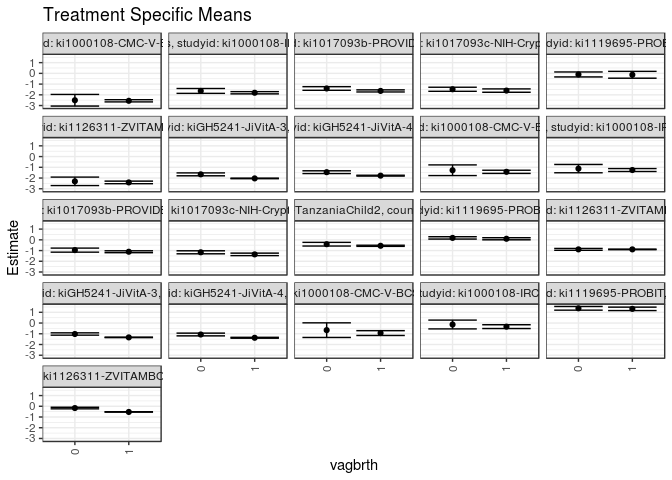

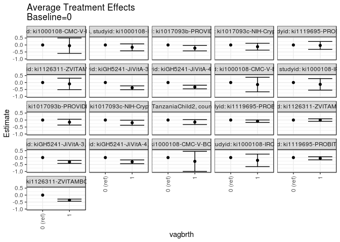

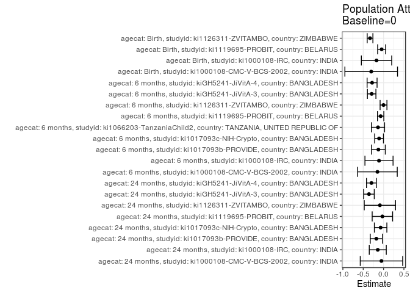

## Results Table

### Parameter: TSM

| agecat | studyid | country | intervention_level | baseline_level | estimate | ci_lower | ci_upper |
| --- | --- | --- | --- | --- | --- | --- | --- |
| Birth | ki1000108-CMC-V-BCS-2002 | INDIA | 0 | NA | -0.6616190 | -1.3439333 | 0.0206953 |
| Birth | ki1000108-CMC-V-BCS-2002 | INDIA | 1 | NA | -0.9336653 | -1.1565460 | -0.7107845 |
| Birth | ki1000108-IRC | INDIA | 0 | NA | -0.1350163 | -0.5437701 | 0.2737374 |
| Birth | ki1000108-IRC | INDIA | 1 | NA | -0.3345119 | -0.5111092 | -0.1579147 |
| Birth | ki1119695-PROBIT | BELARUS | 0 | NA | 1.3728619 | 1.2000816 | 1.5456422 |
| Birth | ki1119695-PROBIT | BELARUS | 1 | NA | 1.3223045 | 1.1616591 | 1.4829498 |
| Birth | ki1126311-ZVITAMBO | ZIMBABWE | 0 | NA | -0.1652860 | -0.2380799 | -0.0924921 |
| Birth | ki1126311-ZVITAMBO | ZIMBABWE | 1 | NA | -0.5282018 | -0.5497860 | -0.5066177 |
| 6 months | ki1000108-CMC-V-BCS-2002 | INDIA | 0 | NA | -1.2726962 | -1.7701402 | -0.7752522 |
| 6 months | ki1000108-CMC-V-BCS-2002 | INDIA | 1 | NA | -1.4193853 | -1.5663824 | -1.2723882 |
| 6 months | ki1000108-IRC | INDIA | 0 | NA | -1.1220207 | -1.5100761 | -0.7339654 |
| 6 months | ki1000108-IRC | INDIA | 1 | NA | -1.2533322 | -1.3908994 | -1.1157650 |
| 6 months | ki1017093b-PROVIDE | BANGLADESH | 0 | NA | -0.9601067 | -1.1500329 | -0.7701804 |
| 6 months | ki1017093b-PROVIDE | BANGLADESH | 1 | NA | -1.1116262 | -1.1992169 | -1.0240355 |
| 6 months | ki1017093c-NIH-Crypto | BANGLADESH | 0 | NA | -1.1629155 | -1.3029501 | -1.0228809 |
| 6 months | ki1017093c-NIH-Crypto | BANGLADESH | 1 | NA | -1.3569162 | -1.4727585 | -1.2410739 |
| 6 months | ki1066203-TanzaniaChild2 | TANZANIA, UNITED REPUBLIC OF | 0 | NA | -0.4090689 | -0.5788987 | -0.2392391 |
| 6 months | ki1066203-TanzaniaChild2 | TANZANIA, UNITED REPUBLIC OF | 1 | NA | -0.5562338 | -0.6079563 | -0.5045112 |
| 6 months | ki1119695-PROBIT | BELARUS | 0 | NA | 0.1784898 | 0.0705338 | 0.2864458 |
| 6 months | ki1119695-PROBIT | BELARUS | 1 | NA | 0.0972748 | 0.0007999 | 0.1937497 |
| 6 months | ki1126311-ZVITAMBO | ZIMBABWE | 0 | NA | -0.8905059 | -0.9777574 | -0.8032544 |
| 6 months | ki1126311-ZVITAMBO | ZIMBABWE | 1 | NA | -0.8909603 | -0.9184307 | -0.8634900 |
| 6 months | kiGH5241-JiVitA-3 | BANGLADESH | 0 | NA | -1.0209009 | -1.1287086 | -0.9130932 |
| 6 months | kiGH5241-JiVitA-3 | BANGLADESH | 1 | NA | -1.3363528 | -1.3595162 | -1.3131895 |
| 6 months | kiGH5241-JiVitA-4 | BANGLADESH | 0 | NA | -1.0678492 | -1.1954877 | -0.9402107 |
| 6 months | kiGH5241-JiVitA-4 | BANGLADESH | 1 | NA | -1.3732874 | -1.4170186 | -1.3295563 |
| 24 months | ki1000108-CMC-V-BCS-2002 | INDIA | 0 | NA | -2.5073392 | -3.0495539 | -1.9651245 |
| 24 months | ki1000108-CMC-V-BCS-2002 | INDIA | 1 | NA | -2.5579000 | -2.6604110 | -2.4553889 |
| 24 months | ki1000108-IRC | INDIA | 0 | NA | -1.6400731 | -1.8667929 | -1.4133532 |
| 24 months | ki1000108-IRC | INDIA | 1 | NA | -1.8084926 | -1.9127053 | -1.7042799 |
| 24 months | ki1017093b-PROVIDE | BANGLADESH | 0 | NA | -1.4089147 | -1.5779269 | -1.2399024 |
| 24 months | ki1017093b-PROVIDE | BANGLADESH | 1 | NA | -1.6365616 | -1.7334833 | -1.5396399 |
| 24 months | ki1017093c-NIH-Crypto | BANGLADESH | 0 | NA | -1.4829464 | -1.6733604 | -1.2925323 |
| 24 months | ki1017093c-NIH-Crypto | BANGLADESH | 1 | NA | -1.6057558 | -1.7619552 | -1.4495564 |
| 24 months | ki1119695-PROBIT | BELARUS | 0 | NA | -0.1025581 | -0.3340438 | 0.1289276 |
| 24 months | ki1119695-PROBIT | BELARUS | 1 | NA | -0.1336500 | -0.4512329 | 0.1839330 |
| 24 months | ki1126311-ZVITAMBO | ZIMBABWE | 0 | NA | -2.3081846 | -2.7030441 | -1.9133251 |
| 24 months | ki1126311-ZVITAMBO | ZIMBABWE | 1 | NA | -2.4076762 | -2.5281421 | -2.2872102 |
| 24 months | kiGH5241-JiVitA-3 | BANGLADESH | 0 | NA | -1.6543845 | -1.7899651 | -1.5188039 |
| 24 months | kiGH5241-JiVitA-3 | BANGLADESH | 1 | NA | -2.0331833 | -2.0607525 | -2.0056141 |
| 24 months | kiGH5241-JiVitA-4 | BANGLADESH | 0 | NA | -1.4527916 | -1.5813384 | -1.3242448 |
| 24 months | kiGH5241-JiVitA-4 | BANGLADESH | 1 | NA | -1.7766270 | -1.8157413 | -1.7375126 |

### Parameter: E(Y)

| agecat | studyid | country | intervention_level | baseline_level | estimate | ci_lower | ci_upper |
| --- | --- | --- | --- | --- | --- | --- | --- |
| Birth | ki1000108-CMC-V-BCS-2002 | INDIA | NA | NA | -0.9654444 | -1.1742112 | -0.7566777 |
| Birth | ki1000108-IRC | INDIA | NA | NA | -0.3080412 | -0.4687931 | -0.1472894 |
| Birth | ki1119695-PROBIT | BELARUS | NA | NA | 1.3254775 | 1.1669293 | 1.4840258 |
| Birth | ki1126311-ZVITAMBO | ZIMBABWE | NA | NA | -0.4977661 | -0.5184205 | -0.4771117 |
| 6 months | ki1000108-CMC-V-BCS-2002 | INDIA | NA | NA | -1.4234508 | -1.5645974 | -1.2823042 |
| 6 months | ki1000108-IRC | INDIA | NA | NA | -1.2344062 | -1.3658524 | -1.1029600 |
| 6 months | ki1017093b-PROVIDE | BANGLADESH | NA | NA | -1.0871041 | -1.1635539 | -1.0106543 |
| 6 months | ki1017093c-NIH-Crypto | BANGLADESH | NA | NA | -1.2731619 | -1.3626957 | -1.1836282 |
| 6 months | ki1066203-TanzaniaChild2 | TANZANIA, UNITED REPUBLIC OF | NA | NA | -0.5455565 | -0.5948696 | -0.4962435 |
| 6 months | ki1119695-PROBIT | BELARUS | NA | NA | 0.1069986 | 0.0122286 | 0.2017686 |
| 6 months | ki1126311-ZVITAMBO | ZIMBABWE | NA | NA | -0.8916778 | -0.9177946 | -0.8655610 |
| 6 months | kiGH5241-JiVitA-3 | BANGLADESH | NA | NA | -1.3134013 | -1.3366073 | -1.2901952 |
| 6 months | kiGH5241-JiVitA-4 | BANGLADESH | NA | NA | -1.3500888 | -1.3921730 | -1.3080047 |
| 24 months | ki1000108-CMC-V-BCS-2002 | INDIA | NA | NA | -2.5593683 | -2.6601027 | -2.4586339 |
| 24 months | ki1000108-IRC | INDIA | NA | NA | -1.7824776 | -1.8765600 | -1.6883952 |
| 24 months | ki1017093b-PROVIDE | BANGLADESH | NA | NA | -1.5861179 | -1.6693668 | -1.5028689 |
| 24 months | ki1017093c-NIH-Crypto | BANGLADESH | NA | NA | -1.5552692 | -1.6759022 | -1.4346363 |
| 24 months | ki1119695-PROBIT | BELARUS | NA | NA | -0.1314048 | -0.4282725 | 0.1654630 |
| 24 months | ki1126311-ZVITAMBO | ZIMBABWE | NA | NA | -2.3985333 | -2.5145993 | -2.2824674 |
| 24 months | kiGH5241-JiVitA-3 | BANGLADESH | NA | NA | -2.0134681 | -2.0411635 | -1.9857727 |
| 24 months | kiGH5241-JiVitA-4 | BANGLADESH | NA | NA | -1.7509129 | -1.7892403 | -1.7125856 |

### Parameter: ATE

| agecat | studyid | country | intervention_level | baseline_level | estimate | ci_lower | ci_upper |
| --- | --- | --- | --- | --- | --- | --- | --- |
| Birth | ki1000108-CMC-V-BCS-2002 | INDIA | 0 | 0 | 0.0000000 | 0.0000000 | 0.0000000 |
| Birth | ki1000108-CMC-V-BCS-2002 | INDIA | 1 | 0 | -0.2720463 | -0.9930445 | 0.4489519 |
| Birth | ki1000108-IRC | INDIA | 0 | 0 | 0.0000000 | 0.0000000 | 0.0000000 |
| Birth | ki1000108-IRC | INDIA | 1 | 0 | -0.1994956 | -0.6487020 | 0.2497108 |
| Birth | ki1119695-PROBIT | BELARUS | 0 | 0 | 0.0000000 | 0.0000000 | 0.0000000 |
| Birth | ki1119695-PROBIT | BELARUS | 1 | 0 | -0.0505574 | -0.1614329 | 0.0603181 |
| Birth | ki1126311-ZVITAMBO | ZIMBABWE | 0 | 0 | 0.0000000 | 0.0000000 | 0.0000000 |
| Birth | ki1126311-ZVITAMBO | ZIMBABWE | 1 | 0 | -0.3629158 | -0.4388332 | -0.2869984 |
| 6 months | ki1000108-CMC-V-BCS-2002 | INDIA | 0 | 0 | 0.0000000 | 0.0000000 | 0.0000000 |
| 6 months | ki1000108-CMC-V-BCS-2002 | INDIA | 1 | 0 | -0.1466891 | -0.6677882 | 0.3744100 |
| 6 months | ki1000108-IRC | INDIA | 0 | 0 | 0.0000000 | 0.0000000 | 0.0000000 |
| 6 months | ki1000108-IRC | INDIA | 1 | 0 | -0.1313115 | -0.5448641 | 0.2822411 |
| 6 months | ki1017093b-PROVIDE | BANGLADESH | 0 | 0 | 0.0000000 | 0.0000000 | 0.0000000 |
| 6 months | ki1017093b-PROVIDE | BANGLADESH | 1 | 0 | -0.1515196 | -0.3605258 | 0.0574866 |
| 6 months | ki1017093c-NIH-Crypto | BANGLADESH | 0 | 0 | 0.0000000 | 0.0000000 | 0.0000000 |
| 6 months | ki1017093c-NIH-Crypto | BANGLADESH | 1 | 0 | -0.1940007 | -0.3750366 | -0.0129648 |
| 6 months | ki1066203-TanzaniaChild2 | TANZANIA, UNITED REPUBLIC OF | 0 | 0 | 0.0000000 | 0.0000000 | 0.0000000 |
| 6 months | ki1066203-TanzaniaChild2 | TANZANIA, UNITED REPUBLIC OF | 1 | 0 | -0.1471648 | -0.3238864 | 0.0295567 |
| 6 months | ki1119695-PROBIT | BELARUS | 0 | 0 | 0.0000000 | 0.0000000 | 0.0000000 |
| 6 months | ki1119695-PROBIT | BELARUS | 1 | 0 | -0.0812150 | -0.1679750 | 0.0055451 |
| 6 months | ki1126311-ZVITAMBO | ZIMBABWE | 0 | 0 | 0.0000000 | 0.0000000 | 0.0000000 |
| 6 months | ki1126311-ZVITAMBO | ZIMBABWE | 1 | 0 | -0.0004544 | -0.0916100 | 0.0907012 |
| 6 months | kiGH5241-JiVitA-3 | BANGLADESH | 0 | 0 | 0.0000000 | 0.0000000 | 0.0000000 |
| 6 months | kiGH5241-JiVitA-3 | BANGLADESH | 1 | 0 | -0.3154520 | -0.4241523 | -0.2067516 |
| 6 months | kiGH5241-JiVitA-4 | BANGLADESH | 0 | 0 | 0.0000000 | 0.0000000 | 0.0000000 |
| 6 months | kiGH5241-JiVitA-4 | BANGLADESH | 1 | 0 | -0.3054382 | -0.4390838 | -0.1717926 |
| 24 months | ki1000108-CMC-V-BCS-2002 | INDIA | 0 | 0 | 0.0000000 | 0.0000000 | 0.0000000 |
| 24 months | ki1000108-CMC-V-BCS-2002 | INDIA | 1 | 0 | -0.0505608 | -0.6028915 | 0.5017699 |
| 24 months | ki1000108-IRC | INDIA | 0 | 0 | 0.0000000 | 0.0000000 | 0.0000000 |
| 24 months | ki1000108-IRC | INDIA | 1 | 0 | -0.1684196 | -0.4181706 | 0.0813315 |
| 24 months | ki1017093b-PROVIDE | BANGLADESH | 0 | 0 | 0.0000000 | 0.0000000 | 0.0000000 |
| 24 months | ki1017093b-PROVIDE | BANGLADESH | 1 | 0 | -0.2276469 | -0.4215421 | -0.0337517 |
| 24 months | ki1017093c-NIH-Crypto | BANGLADESH | 0 | 0 | 0.0000000 | 0.0000000 | 0.0000000 |
| 24 months | ki1017093c-NIH-Crypto | BANGLADESH | 1 | 0 | -0.1228094 | -0.3694020 | 0.1237831 |
| 24 months | ki1119695-PROBIT | BELARUS | 0 | 0 | 0.0000000 | 0.0000000 | 0.0000000 |
| 24 months | ki1119695-PROBIT | BELARUS | 1 | 0 | -0.0310919 | -0.3136407 | 0.2514570 |
| 24 months | ki1126311-ZVITAMBO | ZIMBABWE | 0 | 0 | 0.0000000 | 0.0000000 | 0.0000000 |
| 24 months | ki1126311-ZVITAMBO | ZIMBABWE | 1 | 0 | -0.0994915 | -0.5094098 | 0.3104267 |
| 24 months | kiGH5241-JiVitA-3 | BANGLADESH | 0 | 0 | 0.0000000 | 0.0000000 | 0.0000000 |
| 24 months | kiGH5241-JiVitA-3 | BANGLADESH | 1 | 0 | -0.3787988 | -0.5153034 | -0.2422942 |
| 24 months | kiGH5241-JiVitA-4 | BANGLADESH | 0 | 0 | 0.0000000 | 0.0000000 | 0.0000000 |
| 24 months | kiGH5241-JiVitA-4 | BANGLADESH | 1 | 0 | -0.3238353 | -0.4548933 | -0.1927774 |

### Parameter: PAR

| agecat | studyid | country | intervention_level | baseline_level | estimate | ci_lower | ci_upper |
| --- | --- | --- | --- | --- | --- | --- | --- |
| Birth | ki1000108-CMC-V-BCS-2002 | INDIA | 0 | NA | -0.3038254 | -0.9507848 | 0.3431339 |
| Birth | ki1000108-IRC | INDIA | 0 | NA | -0.1730249 | -0.5457341 | 0.1996843 |
| Birth | ki1119695-PROBIT | BELARUS | 0 | NA | -0.0473843 | -0.1452555 | 0.0504868 |
| Birth | ki1126311-ZVITAMBO | ZIMBABWE | 0 | NA | -0.3324801 | -0.4023677 | -0.2625925 |
| 6 months | ki1000108-CMC-V-BCS-2002 | INDIA | 0 | NA | -0.1507546 | -0.6378575 | 0.3363484 |
| 6 months | ki1000108-IRC | INDIA | 0 | NA | -0.1123855 | -0.4578116 | 0.2330406 |
| 6 months | ki1017093b-PROVIDE | BANGLADESH | 0 | NA | -0.1269974 | -0.2960947 | 0.0420999 |
| 6 months | ki1017093c-NIH-Crypto | BANGLADESH | 0 | NA | -0.1102464 | -0.2181730 | -0.0023198 |
| 6 months | ki1066203-TanzaniaChild2 | TANZANIA, UNITED REPUBLIC OF | 0 | NA | -0.1364876 | -0.2985924 | 0.0256172 |
| 6 months | ki1119695-PROBIT | BELARUS | 0 | NA | -0.0714912 | -0.1492907 | 0.0063084 |
| 6 months | ki1126311-ZVITAMBO | ZIMBABWE | 0 | NA | -0.0011719 | -0.0851652 | 0.0828213 |
| 6 months | kiGH5241-JiVitA-3 | BANGLADESH | 0 | NA | -0.2925004 | -0.3968596 | -0.1881411 |
| 6 months | kiGH5241-JiVitA-4 | BANGLADESH | 0 | NA | -0.2822396 | -0.4046711 | -0.1598081 |
| 24 months | ki1000108-CMC-V-BCS-2002 | INDIA | 0 | NA | -0.0520291 | -0.5732522 | 0.4691940 |
| 24 months | ki1000108-IRC | INDIA | 0 | NA | -0.1424045 | -0.3515374 | 0.0667284 |
| 24 months | ki1017093b-PROVIDE | BANGLADESH | 0 | NA | -0.1772032 | -0.3266720 | -0.0277344 |
| 24 months | ki1017093c-NIH-Crypto | BANGLADESH | 0 | NA | -0.0723229 | -0.2255196 | 0.0808739 |
| 24 months | ki1119695-PROBIT | BELARUS | 0 | NA | -0.0288467 | -0.2799976 | 0.2223042 |
| 24 months | ki1126311-ZVITAMBO | ZIMBABWE | 0 | NA | -0.0903487 | -0.4744025 | 0.2937051 |
| 24 months | kiGH5241-JiVitA-3 | BANGLADESH | 0 | NA | -0.3590836 | -0.4897592 | -0.2284079 |
| 24 months | kiGH5241-JiVitA-4 | BANGLADESH | 0 | NA | -0.2981213 | -0.4193976 | -0.1768450 |